# DATA 605 FUNDAMENTALS OF COMPUTATIONAL MATHEMATICS

Homework Week 12: Multiple Linear Regression

Kyle Gilde

11/16/2017

```
##           installed_and_loaded.packages.
## prettydoc                           TRUE
## dplyr                               TRUE
## ggplot2                             TRUE
## gvlma                               TRUE
## MASS                                TRUE
## lmtest                              TRUE
## car                                 TRUE
```

# The Data

**The attached who.csv dataset contains real-world data from 2008. The variables included following:**

- Country: name of the country
- LifeExp: average life expectancy for the country in years
- InfantSurvival: proportion of those surviving to one year or more
- Under5Survival: proportion of those surviving to five years or more
- TBFree: proportion of the population without TB.
- PropMD: proportion of the population who are MDs
- PropRN: proportion of the population who are RNs
- PersExp: mean personal expenditures on healthcare in US dollars at average exchange rate
- GovtExp: mean government expenditures per capita on healthcare, US dollars at average exchange rate
- TotExp: sum of personal and government expenditures.

```r
url <- "https://raw.githubusercontent.com/kylegilde/D605-Math/master/who.csv"

who_df <- read.csv(url)

glimpse(who_df)
```

```
## Observations: 190
## Variables: 10
## $ Country        <fctr> Afghanistan, Albania, Algeria, Andorra, Angola...
## $ LifeExp        <int> 42, 71, 71, 82, 41, 73, 75, 69, 82, 80, 64, 74,...
## $ InfantSurvival <dbl> 0.835, 0.985, 0.967, 0.997, 0.846, 0.990, 0.986...
## $ Under5Survival <dbl> 0.743, 0.983, 0.962, 0.996, 0.740, 0.989, 0.983...
## $ TBFree         <dbl> 0.99769, 0.99974, 0.99944, 0.99983, 0.99656, 0....
## $ PropMD         <dbl> 0.000228841, 0.001143127, 0.001060478, 0.003297...
## $ PropRN         <dbl> 0.000572294, 0.004614439, 0.002091362, 0.003500...
## $ PersExp        <int> 20, 169, 108, 2589, 36, 503, 484, 88, 3181, 378...
## $ GovtExp        <int> 92, 3128, 5184, 169725, 1620, 12543, 19170, 185...
## $ TotExp         <int> 112, 3297, 5292, 172314, 1656, 13046, 19654, 19...
```

# Questions

## 1. Provide a scatterplot of LifeExp~TotExp, and run simple linear regression. Do not transform the variables. Provide and interpret the F statistics, R^2, standard error,and p-values only. Discuss whether the assumptions of simple linear regression met.

### Model Summary

```r
options(scipen = 6)
summary(who_df[c("LifeExp", "TotExp")])
```

```
##     LifeExp          TotExp
##  Min.   :40.00   Min.   :    13
##  1st Qu.:61.25   1st Qu.:   584
##  Median :70.00   Median :  5541
##  Mean   :67.38   Mean   : 41696
##  3rd Qu.:75.00   3rd Qu.: 26331
##  Max.   :83.00   Max.   :482750
```

```r
who_model <- lm(LifeExp ~ TotExp, who_df)
summary(who_model)
```

```
##
## Call:
## lm(formula = LifeExp ~ TotExp, data = who_df)
##
## Residuals:
##     Min      1Q  Median      3Q     Max
## -24.764  -4.778   3.154   7.116  13.292
##
## Coefficients:
##                 Estimate   Std. Error t value Pr(>|t|)
## (Intercept) 64.753374534  0.753536611  85.933  < 2e-16 ***
## TotExp       0.000062970  0.000007795   8.079 7.71e-14 ***
## ---
## Signif. codes:  0 '***' 0.001 '**' 0.01 '*' 0.05 '.' 0.1 ' ' 1
##
## Residual standard error: 9.371 on 188 degrees of freedom
## Multiple R-squared:  0.2577, Adjusted R-squared:  0.2537
## F-statistic: 65.26 on 1 and 188 DF,  p-value: 7.714e-14
```

```r
intercept <- coef(who_model)[1]
slope <- coef(who_model)[2]
```

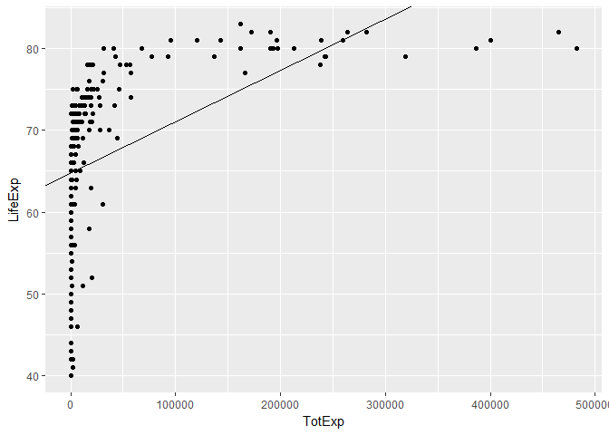

```r
a <- ggplot(who_model, aes(TotExp, LifeExp))
a + geom_point() + geom_abline(slope = slope, intercept = intercept, show.legend = TRUE)
```

### Model Diagnostics

Let’s assess if this linear model is reliable.

#### Linearity: Do the variables have a linear relationship?

The Component+Residual plot shows that this is NOT a linear relationship.

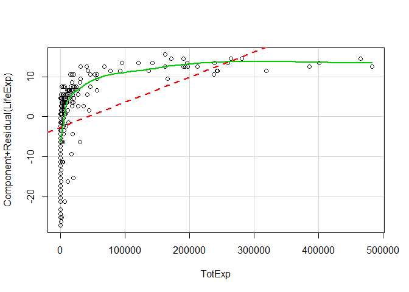

```r
crPlots(who_model)
```

#### Normality: Are the model’s residuals LifeExpributed nearly normally?

No, per the histogram and Q-Q plot, the residuals are not anywhere near normally distributed.

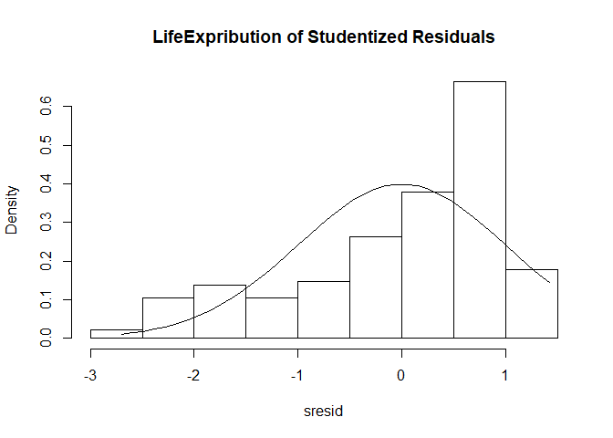

```r
sresid <- studres(who_model)
hist(sresid, freq = FALSE, breaks = 10, main = "LifeExpribution of Studentized Residuals")
xfit <- seq(min(sresid), max(sresid), length = 40)
yfit <- dnorm(xfit)
lines(xfit, yfit)
```

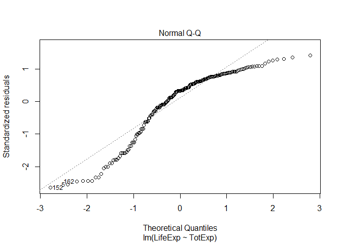

```r
plot(who_model, which = 2)
```

#### Homoscedasticity: Is there constant variability among the residuals?

- Based on the scatter plot, the residuals are not indistinctly distributed.
- The Non-constant Variance Score Test has a p-value of >.05, which indicates that we would fail to reject the null hypothesis of homoscedasticity.

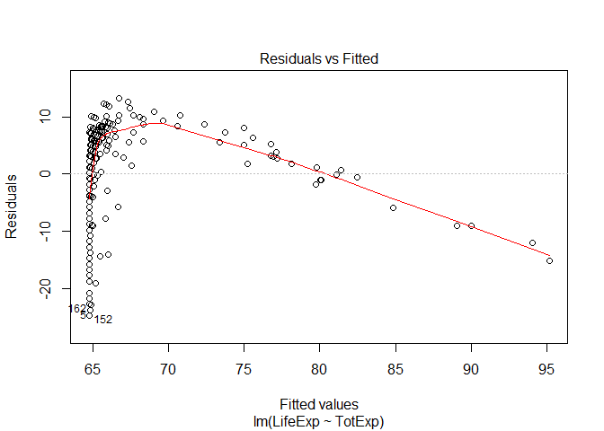

```r
plot(who_model, which = 1)
```

```r
ncvTest(who_model)
```

```
## Non-constant Variance Score Test
## Variance formula: ~ fitted.values
## Chisquare = 2.599177    Df = 1     p = 0.1069193
```

#### Independence: Are the data from a random sample and not from a time series?

The Durbin Watson test’s p-value is >.05. Therefore, we fail to reject the null hypothesis of independence (no autocorrelation).

```r
durbinWatsonTest(who_model)
```

```
##  lag Autocorrelation D-W Statistic p-value
##    1      0.06872515      1.802451   0.166
##  Alternative hypothesis: rho != 0
```

#### Conclusion

While the coefficient values are likely relevant to modeling LifeExp, based upon my diagnostics and the gvlma function, the conditions for linear regression have not been met.

```r
gvlma(who_model)
```

```
##
## Call:
## lm(formula = LifeExp ~ TotExp, data = who_df)
##
## Coefficients:
## (Intercept)       TotExp
## 64.75337453   0.00006297
##
##
## ASSESSMENT OF THE LINEAR MODEL ASSUMPTIONS
## USING THE GLOBAL TEST ON 4 DEGREES-OF-FREEDOM:
## Level of Significance =  0.05
##
## Call:
##  gvlma(x = who_model)
##
##                        Value   p-value                   Decision
## Global Stat        56.737011 1.405e-11 Assumptions NOT satisfied!
## Skewness           30.532757 3.283e-08 Assumptions NOT satisfied!
## Kurtosis            0.002804 9.578e-01    Assumptions acceptable.
## Link Function      26.074703 3.285e-07 Assumptions NOT satisfied!
## Heteroscedasticity  0.126747 7.218e-01    Assumptions acceptable.
```

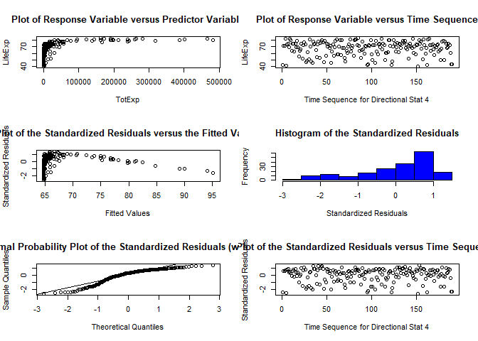

```r
plot(gvlma(who_model))
```

## 2. Raise life expectancy to the 4.6 power (i.e., LifeExp^4.6). Raise total expenditures to the 0.06 power (nearly a log transform, TotExp^.06). Plot LifeExp^4.6 as a function of TotExp^.06, and re-run the simple regression model using the transformed variables. Provide and interpret the F statistics, R^2, standard error, and p-values. Which model is “better?”

### Model Summary

```r
options(scipen = 0)
options(digits = 6)

who_df$LifeExp4.6 <- who_df$LifeExp^4.6
who_df$TotExp.06 <- who_df$TotExp^0.06

who_model <- lm(LifeExp4.6 ~ TotExp.06, who_df)
summary(who_model)
```

```
##
## Call:
## lm(formula = LifeExp4.6 ~ TotExp.06, data = who_df)
##
## Residuals:
##       Min        1Q    Median        3Q       Max
## -3.09e+08 -5.40e+07  1.37e+07  5.91e+07  2.12e+08
##
## Coefficients:
##              Estimate Std. Error t value Pr(>|t|)
## (Intercept) -7.37e+08   4.68e+07   -15.7   <2e-16 ***
## TotExp.06    6.20e+08   2.75e+07    22.5   <2e-16 ***
## ---
## Signif. codes:  0 '***' 0.001 '**' 0.01 '*' 0.05 '.' 0.1 ' ' 1
##
## Residual standard error: 90500000 on 188 degrees of freedom
## Multiple R-squared:  0.73,   Adjusted R-squared:  0.728
## F-statistic:  508 on 1 and 188 DF,  p-value: <2e-16
```

```r
intercept <- coef(who_model)[1]
slope <- coef(who_model)[2]
```

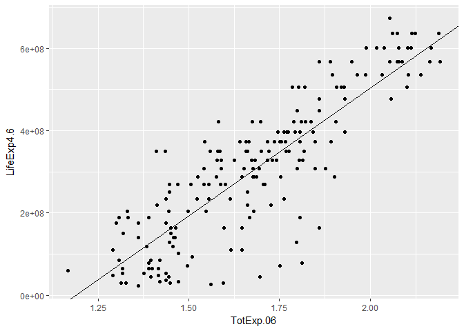

```r
a <- ggplot(who_model, aes(TotExp.06, LifeExp4.6))
a + geom_point() + geom_abline(slope = slope, intercept = intercept, show.legend = TRUE)
```

### Model Interpretation

```r
90500000^(1/4.6)
```

```
## [1] 53.6669
```

- In this model, multiple $R^2$ is 0.728, which means that $72\%$ of the variance in the response variable can be explained by the independent variable.
- The F-statistic at 508 is quite large, and the model’s p-value is near zero. If the model’s diagnostics are sufficient, these values indicate that we would reject the null hypothesis that there is no relationship between the variables.

### Model Diagnostics

Let’s assess if this linear model is reliable.

#### Linearity: Do the variables have a linear relationship?

The Component+Residual plot shows that this is now a linear relationship.

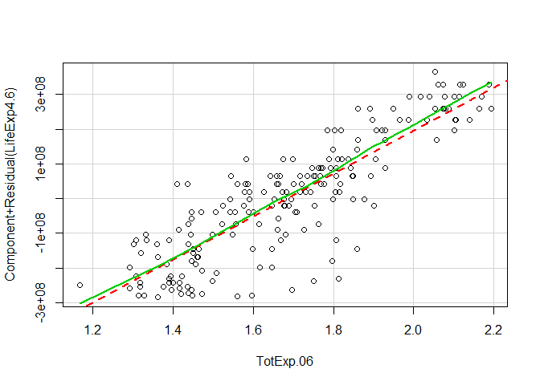

```r
crPlots(who_model)
```

#### Normality: Are the model’s residuals LifeExp4.6ributed nearly normally?

Per the histogram and Q-Q plot, the residuals are more normally distributed. However, they are left skewed.

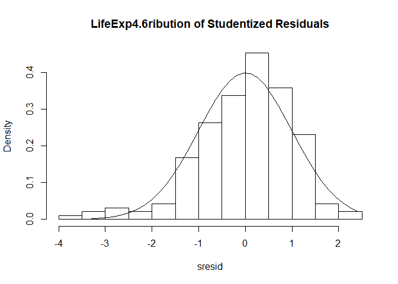

```r
sresid <- studres(who_model)
hist(sresid, freq = FALSE, breaks = 10, main = "LifeExp4.6ribution of Studentized Residuals")
xfit <- seq(min(sresid), max(sresid), length = 40)
yfit <- dnorm(xfit)
lines(xfit, yfit)
```

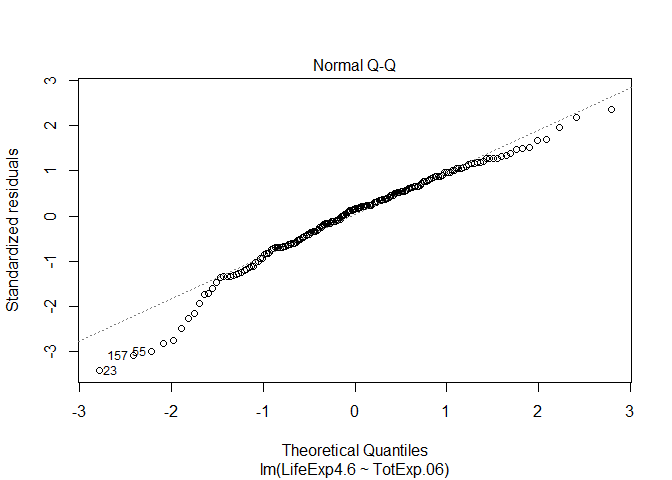

```r
plot(who_model, which = 2)
```

#### Homoscedasticity: Is there constant variability among the residuals?

- Based on the scatter plot, the residuals are much more indistinctly distributed vis-a-vis the fitted values, but not completely so.
- The Non-constant Variance Score Test has a p-value of >.05, which indicates that we would fail to reject the null hypothesis of homoscedasticity.

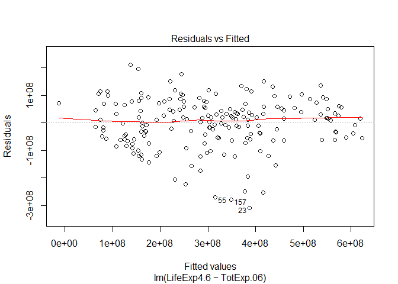

```r
plot(who_model, which = 1)
```

```r
ncvTest(who_model)
```

```
## Non-constant Variance Score Test
## Variance formula: ~ fitted.values
## Chisquare = 0.427802    Df = 1     p = 0.51307
```

#### Independence: Are the data from a random sample and not from a time series?

The Durbin Watson test’s p-value is >.05. Therefore, we fail to reject the null hypothesis of independence of no autocorrelation).

```r
durbinWatsonTest(who_model)
```

```
##  lag Autocorrelation D-W Statistic p-value
##    1       0.0403816       1.90907   0.524
##  Alternative hypothesis: rho != 0
```

#### Conclusion

```r
gvlma(who_model)
```

```
##
## Call:
## lm(formula = LifeExp4.6 ~ TotExp.06, data = who_df)
##
## Coefficients:
## (Intercept)    TotExp.06
##   -7.37e+08     6.20e+08
##
##
## ASSESSMENT OF THE LINEAR MODEL ASSUMPTIONS
## USING THE GLOBAL TEST ON 4 DEGREES-OF-FREEDOM:
## Level of Significance =  0.05
##
## Call:
##  gvlma(x = who_model)
##
##                    Value  p-value                   Decision
## Global Stat        27.81 1.36e-05 Assumptions NOT satisfied!
## Skewness           17.14 3.48e-05 Assumptions NOT satisfied!
## Kurtosis            7.46 6.32e-03 Assumptions NOT satisfied!
## Link Function       2.99 8.40e-02    Assumptions acceptable.
## Heteroscedasticity  0.23 6.32e-01    Assumptions acceptable.
```

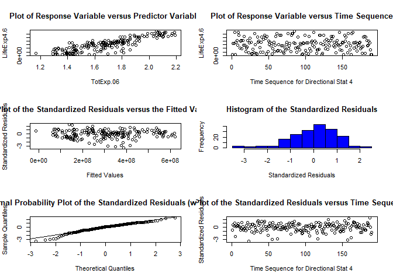

```r
plot(gvlma(who_model))
```

```r
as.numeric(intercept + slope * 2.5)
```

```
## [1] 813622630
```

## 4. Build the following multiple regression model and interpret the F Statistics, R^2, standard error, and p-values. How good is the model?

LifeExp4.6 = b0 + b1 x PropMd + b2 x TotExp.06 + b3 x PropMD x TotExp.06

### Model Summary

```r
who_model <- lm(LifeExp4.6 ~ PropMD + TotExp.06 + PropMD * TotExp.06, who_df)

summary(who_model)
```

```
##
## Call:
## lm(formula = LifeExp4.6 ~ PropMD + TotExp.06 + PropMD * TotExp.06,
##     data = who_df)
##
## Residuals:
##       Min        1Q    Median        3Q       Max
## -2.96e+08 -4.77e+07  1.22e+07  6.03e+07  2.12e+08
##
## Coefficients:
##                   Estimate Std. Error t value Pr(>|t|)
## (Intercept)      -7.24e+08   5.08e+07  -14.25   <2e-16 ***
## PropMD            4.73e+10   2.26e+10    2.09    0.038 *
## TotExp.06         6.05e+08   3.02e+07   20.00   <2e-16 ***
## PropMD:TotExp.06 -2.12e+10   1.13e+10   -1.88    0.062 .
## ---
## Signif. codes:  0 '***' 0.001 '**' 0.01 '*' 0.05 '.' 0.1 ' ' 1
##
## Residual standard error: 88500000 on 186 degrees of freedom
## Multiple R-squared:  0.744,  Adjusted R-squared:  0.74
## F-statistic:  180 on 3 and 186 DF,  p-value: <2e-16
```

### Model Interpretation

- From the residual summary statistics, there may be a possibly skewed distribution not centered around zero, but we will confirm with further diagnostics.
- Using the point estimates of the coefficients, the linear model is expressed as $ = - 7.24e+08 + 4.73e+10PropMD + 6.05e+08TotExp.06 - 2.12e+10PropMD * TotExp.06 $
- For each additional unit increase in PropMD, the model expects on average an increase of 4.73e+10 in LifeExp4.6, holding all other variables constant. For each additional unit increase in TotExp.06, the model expects on average an increase of 6.05e+08 in LifeExp4.6, holding all other variables constant. For each additional unit increase in PropMD:TotExp.06, the model expects on average a decrease of 2.12e+10 in LifeExp4.6, holding all other variables constant.
- The ratio of the coefficents to the standard errors is large for the y-intercept and TotExp.06, but is small for PropMD and PropMD:TotExp.06. Consequently, we can expect little variability in the coefficient estimates of the former 2 and greater variability in the later 2.

```r
coef(summary(who_model))[, 1]/coef(summary(who_model))[, 2]
```

```
##      (Intercept)           PropMD        TotExp.06 PropMD:TotExp.06
##        -14.25318          2.09387         20.00469         -1.87604
```

- The coefficient’s t-values are not very large for PropMD and PropMD:TotExp.06 and their p-values are not near zero like the other 2. PropMD:TotExp.06’s p-value is larger than our significance thresdold.
- The Residual Standard Error seems rather large since 88500000^(1/4.6) = 53.4068 years. This is the average amount that our response variable will deviate from the regression line.

```r
88500000^(1/4.6)
```

```
## [1] 53.4068
```

- In this model, multiple $R^2$ is 0.74, which means that $74\%$ of the variance in the response variable can be explained by the independent variable.
- The F-statistic at 180 is quite large, and the model’s p-value is near zero. If the model’s diagnostics are sufficient, these values indicate that we would reject the null hypothesis that there is no relationship between the variables.

### Model Diagnostics

Let’s assess if this linear model is reliable.

#### Linearity: Do the variables have a linear relationship?

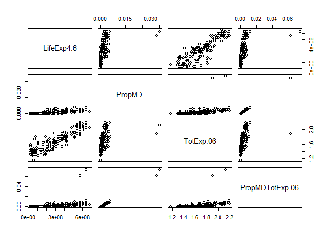

```r
who_df$PropMDTotExp.06 <- who_df$PropMD * who_df$TotExp.06
pairs(subset(who_df, select = c(LifeExp4.6, PropMD, TotExp.06, PropMDTotExp.06)))
```

#### Normality: Are the model’s residuals LifeExp4.6ributed nearly normally?

Per the histogram and Q-Q plot, the residuals are left skewed.

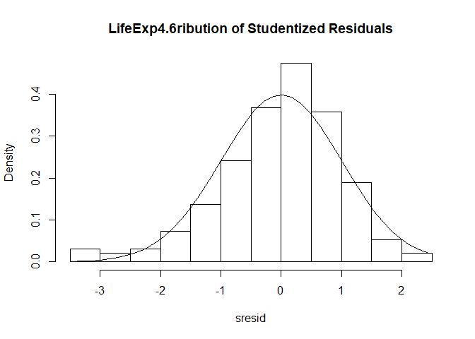

```r
sresid <- studres(who_model)
hist(sresid, freq = FALSE, breaks = 10, main = "LifeExp4.6ribution of Studentized Residuals")
xfit <- seq(min(sresid), max(sresid), length = 40)
yfit <- dnorm(xfit)
lines(xfit, yfit)
```

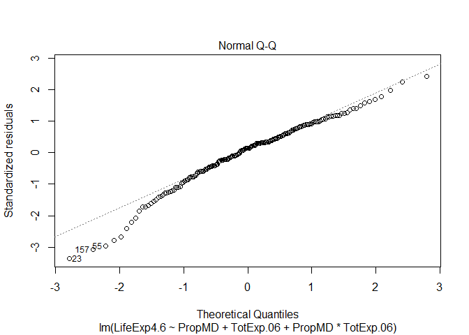

```r
plot(who_model, which = 2)
```

#### Homoscedasticity: Is there constant variability among the residuals?

- Based on the scatter plot, the residuals are somewhat curvilinear.
- The Non-constant Variance Score Test has a p-value of >.05, which indicates that we would fail to reject the null hypothesis of homoscedasticity.

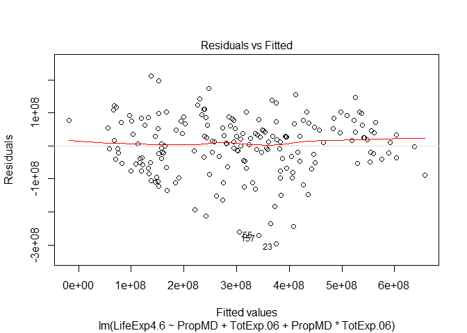

```r
plot(who_model, which = 1)
```

```r
ncvTest(who_model)
```

```
## Non-constant Variance Score Test
## Variance formula: ~ fitted.values
## Chisquare = 0.401179    Df = 1     p = 0.526481
```

#### Independence: Are the data from a random sample and not from a time series?

The Durbin Watson test’s p-value is >.05. Therefore, we fail to reject the null hypothesis of independence, i.e. no autocorrelation).

```r
durbinWatsonTest(who_model)
```

```
##  lag Autocorrelation D-W Statistic p-value
##    1      -0.0037112       1.99799   0.966
##  Alternative hypothesis: rho != 0
```

#### Conclusion

While the Adjusted R-squared at .74 is slightly higher than the 2nd model, I would say that this more complex model is weaker because one of the coefficient p-values is greater than the significance threshold, and 2 of them have large standard errors.

```r
gvlma(who_model)
```

```
##
## Call:
## lm(formula = LifeExp4.6 ~ PropMD + TotExp.06 + PropMD * TotExp.06,
##     data = who_df)
##
## Coefficients:
##      (Intercept)            PropMD         TotExp.06  PropMD:TotExp.06
##        -7.24e+08          4.73e+10          6.05e+08         -2.12e+10
##
##
## ASSESSMENT OF THE LINEAR MODEL ASSUMPTIONS
## USING THE GLOBAL TEST ON 4 DEGREES-OF-FREEDOM:
## Level of Significance =  0.05
##
## Call:
##  gvlma(x = who_model)
##
##                     Value  p-value                   Decision
## Global Stat        26.556 2.44e-05 Assumptions NOT satisfied!
## Skewness           15.231 9.51e-05 Assumptions NOT satisfied!
## Kurtosis            6.681 9.74e-03 Assumptions NOT satisfied!
## Link Function       4.345 3.71e-02 Assumptions NOT satisfied!
## Heteroscedasticity  0.298 5.85e-01    Assumptions acceptable.
```

[figure not shown]

```r
plot(gvlma(who_model))
```

## 5. Forecast LifeExp4.6 when PropMD=.03 and TotExp.06= 14. Does this forecast seem realistic? Why or why not?

No, Given that PropMD = .03 is near the max value and TotExp.06 = 14 is much greater than the variable’s known range, a predicted value of 66.977, which is less than the mean and median does not seem realistic.

```r
options(scipen = 999)
summary(subset(who_df, select = c(PropMD, TotExp.06, LifeExp)))
```

```
##      PropMD            TotExp.06        LifeExp
##  Min.   :0.0000196   Min.   :1.166   Min.   :40.00
##  1st Qu.:0.0002444   1st Qu.:1.465   1st Qu.:61.25
##  Median :0.0010474   Median :1.677   Median :70.00
##  Mean   :0.0017954   Mean   :1.684   Mean   :67.38
##  3rd Qu.:0.0024584   3rd Qu.:1.842   3rd Qu.:75.00
##  Max.   :0.0351290   Max.   :2.193   Max.   :83.00
```

```r
PropMD <- 0.03
TotExp.06 <- 14
coefs <- as.numeric(coef(who_model))

predicted_value <- coefs[1] + coefs[2] * PropMD + coefs[3] * TotExp.06 + coefs[4] *
    PropMD * TotExp.06

predicted_value^(1/4.6)
```

```
## [1] 66.97703
```

# References

https://cran.r-project.org/doc/contrib/Faraway-PRA.pdf

[Interpreting Model Output In R](https://feliperego.github.io/blog/2015/10/23/Interpreting-Model-Output-In-R)

[Global Validation of Linear Models Assumptions](https://www.rdocumentation.org/packages/gvlma/versions/1.0.0.2)

http://r-statistics.co/Assumptions-of-Linear-Regression.html

https://www.statmethods.net/stats/regression.html

http://ademos.people.uic.edu/Chapter12.html#121_example_2:_a_thanksgiving_not_to_remember,_part_2

http://rstatistics.net/how-to-test-a-regression-model-for-heteroscedasticity-and-if-present-how-to-correct-it/

http://www.statisticshowto.com/durbin-watson-test-coefficient/

http://www.ianruginski.com/regressionassumptionswithR_tutorial.html